# Adventures in Public Health Data Analytics - COVID-19 and beyond

2021-09-17 17:31:04

## About me

- Originally from Germany, moved to U.S. for graduate school - and never left 😄.
- PhD in Physics from Georgia Tech, Postdoc in Computational Biology at Emory. Since 2009, Assistant/Associate/Full Professor in Epidemiology & Biostatistics, UGA.
- Data analysis and modeling of infectious diseases on the population level and individual patient level.
- A lot of influenza and norovirus, some other bugs. Recently also a lot of SARS-CoV-2.
- More information:
  - https://www.andreashandel.com
  - https://handelgroup.uga.edu

## Motivation for this talk

- After 15+ years in academia, I want to branch out into some more applied work.
- To get that process started, I want to do a short term (approx. 8 month) industry “internship”.
- This presentation is part of my *looking for something* effort.
- Also, academics just like to talk about their work 😁.

## Presentation overview

- A quick whirlwind of several projects that showcase different topics and approaches.
- Some projects are basic research, some are more applied/operational.
- I’ll describe each project **very** briefly. Happy to go deeper in the Q&A.
- Slides here: https://www.andreashandel.com/presentations/

## A COVID-19 Tracker

## Motivation

- Early in the pandemic, I was part of a team of experts asked to forecast COVID.
- I wanted quick access to data to make (intuitive) forecasts.
- None of the COVID trackers at that time had what I wanted.
- With a few team members, we built our own.

## Methods

- R/Shiny app that pulls data from different sources (JHU, NYT, Covidtracking, etc.)
- Visualize data as time-trends for countries/states/counties.
- Allow for adjustments, e.g. total cases versus per 100K, trend-lines, custom date ranges.

## Results & More Information

- https://shiny.ovpr.uga.edu/yact/
- Collaborators: Robbie Richards, William Norfolk, Gio Righi, Avranil Basu.
- Github repo: https://github.com/CEIDatUGA/COVID-shiny-tracker

## Forecasting COVID in the US

## Motivation

- We want to know how many cases/hospitalizations/deaths to expect.
- A team of scientists coordinated with the CDC to set up a forecasting system: https://covid19forecasthub.org/
- We/UGA are one of the participating teams (somewhat different model).

## Methods

Dynamic, mechanistic (SIR type) model, implemented in R.

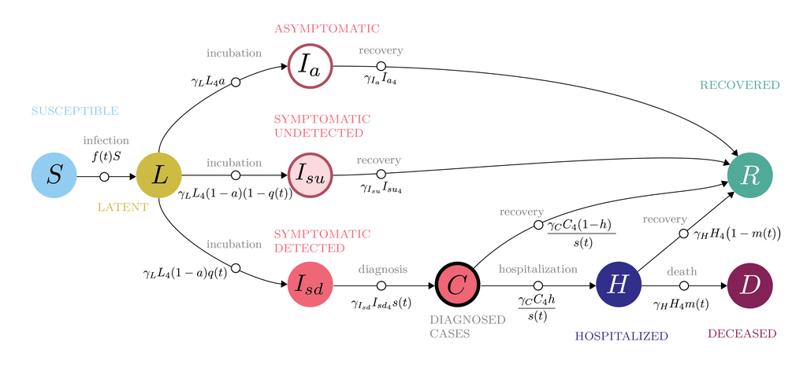

## Results

Model is calibrated by fitting to case and death data for each state, then used to forecast.

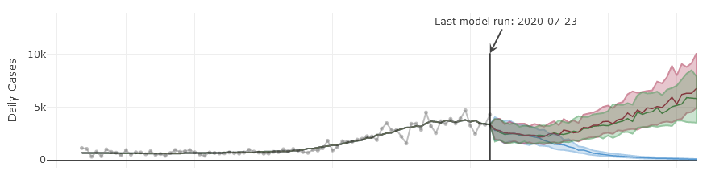

## More Information

- Collaborators: John Drake, Andrew Tredennick, Eamon O’Dea, Tierney O’Sullivan
- More information: https://www.covid19.uga.edu/

## Community Outbreak Investigation of SARS-CoV-2 Transmission Among Bus Riders in Eastern China

## Motivation

- Understanding when and how SARS-CoV-2 transmits is important.
- Getting detailed data was and is difficult.
- We collaborated with colleagues from China to analyze a well-described transmission scenario.

## Methods

- Data from a COVID-19 outbreak entailing 2 buses (bus #2 containing an infected person) going to a temple for an (outdoor) religious ceremony.
- Basic statistical analysis to determine risk of infection.

## Results

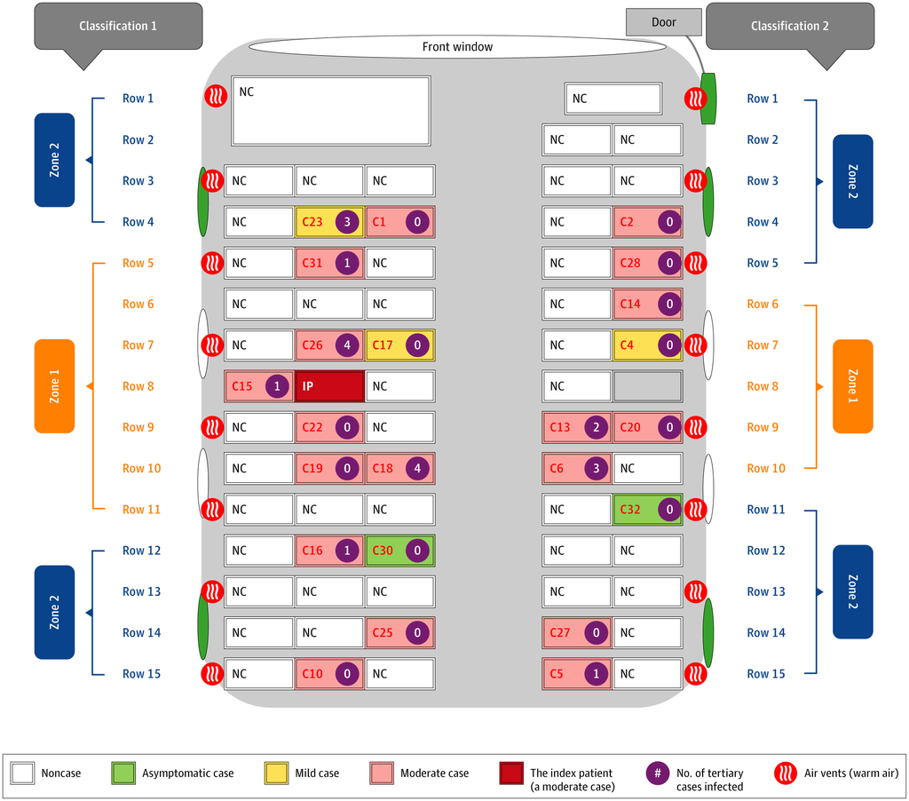

## Results

|  | **Cases** | **Total** | **Attack rate (95% CI)** | **Relative Risk (95% CI)** |
| --- | --- | --- | --- | --- |
| Bus #1 | 0 | 60 | 0 (0–6.0) | 1 (Reference) |
| Bus #2 | 23 | 67 | 34.3 (24.1–46.3) | 42.2 (2.6–679.3) |
| All individuals at ceremony except bus #2 | 7 | 232 | 3.0 (1.3–6.2) | … |
| Overall | 30 | 299 | 10.0 (7.1–14.0) | … |
| Bus #2 Low-risk zones (rows 1-4, 12-15) | 9 | 34 | 26.5 (14.4–43.3) | 1 (Reference) |
| Bus #2 High-risk zone (rows 5-11) | 14 | 33 | 42.4 (27.2–59.2) | 1.6 (0.8–3.2) |

## More Information

- Collaborators: Many. See the paper for a full author list.
- Published paper: https://pubmed.ncbi.nlm.nih.gov/32870239/

## Machine learning to understand predictors of influenza T cell responses

## Motivation

- After infection, individuals mount an immune response. B cells and T cells are important to protect against future infection.
- It is still unclear what immunological mechanisms lead to a good T cell response.
- We analyzed experimental lab data to investigate this.

## Methods

- Linear bivariable and multivariable models.
- Cross-validated subset selection and LASSO regularization to perform variable selection.
- Machine learning methods to investigate performance of more complex models:
  - Support vector machine
  - Random forest
  - Gradient boosted regression tree
- Everything implemented in R.

## Results

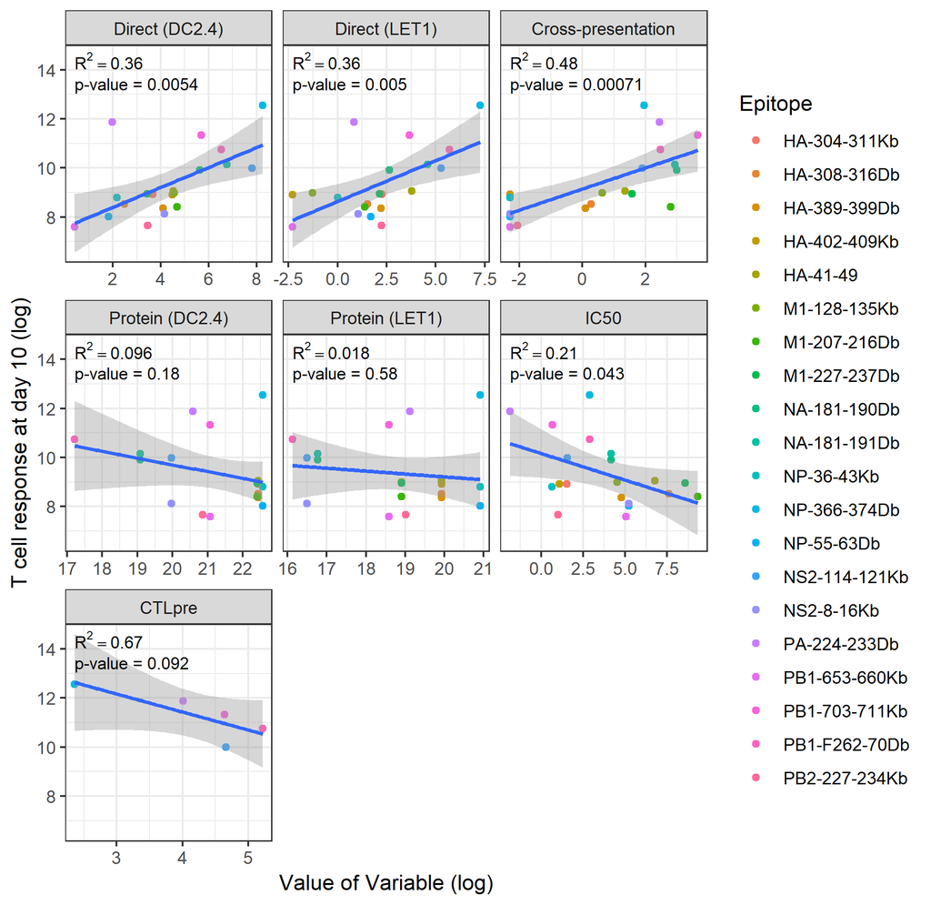

Multivariable linear model with **cross-presentation** and **IC50** performed best. ML models did not improve performance.

## More Information

- Collaborators: Many. See the paper for a full author list.
- Published paper: https://doi.org/10.1038/s41467-019-10661-8

## Overall Summary

- A mix of methods:
  - Statistical modeling/analysis (frequentist and Bayesian)
  - Machine learning
  - Mechanistic simulation models
- A mix of topics:
  - Mostly basic science
  - Some applied work for COVID-19

**Questions?**